# Forecasting Anomalies in Global Temperature

## Diagnostic Check: Correlation Indepedent

```
##
##  Box-Ljung test
##
## data:  residuals(fit.ar3)
## X-squared = 5.1354, df = 9, p-value = 0.8223
```

```
##
##  Box-Ljung test
##
## data:  residuals(fit.ar1ma1)
## X-squared = 8.3917, df = 10, p-value = 0.5906
```

```
##
##  Box-Ljung test
##
## data:  residuals(fit.ar1ma3)
## X-squared = 3.1319, df = 8, p-value = 0.9258
```

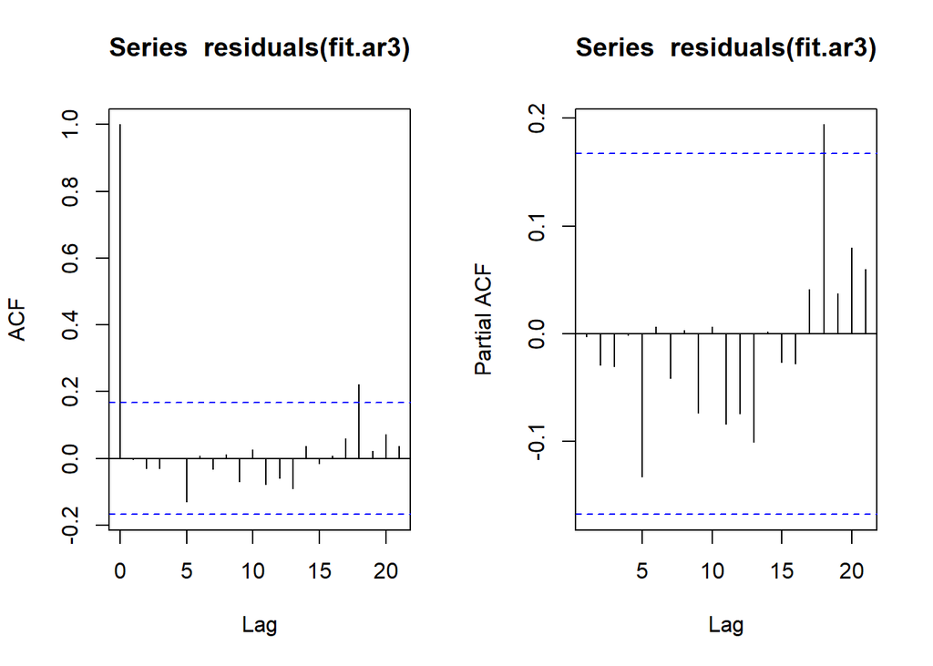

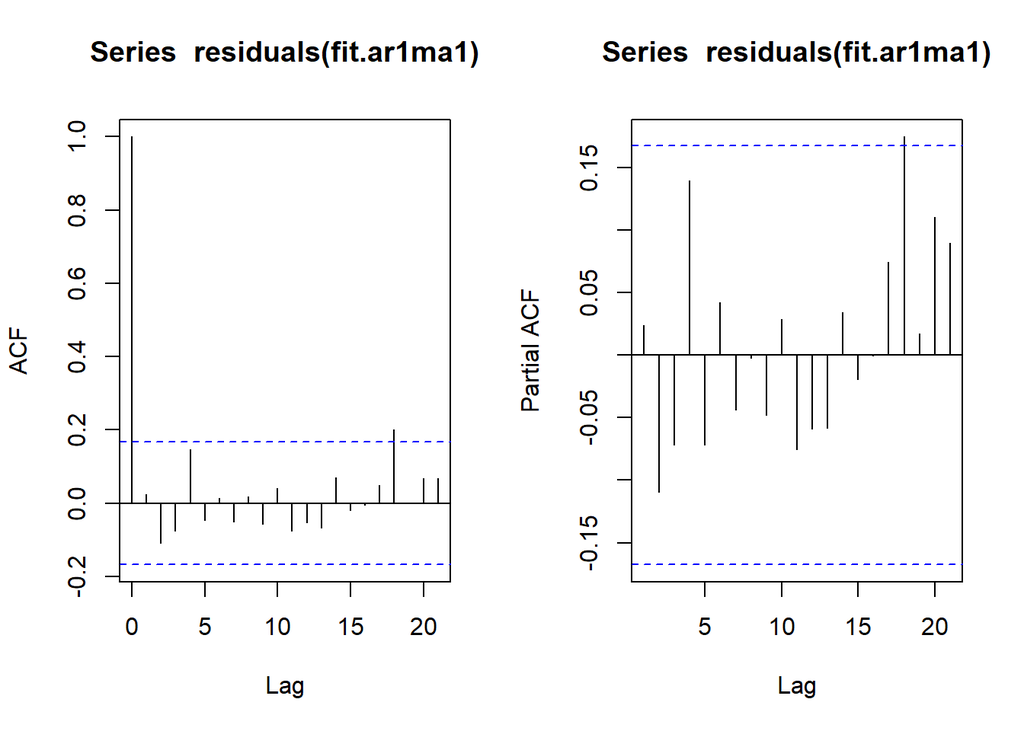

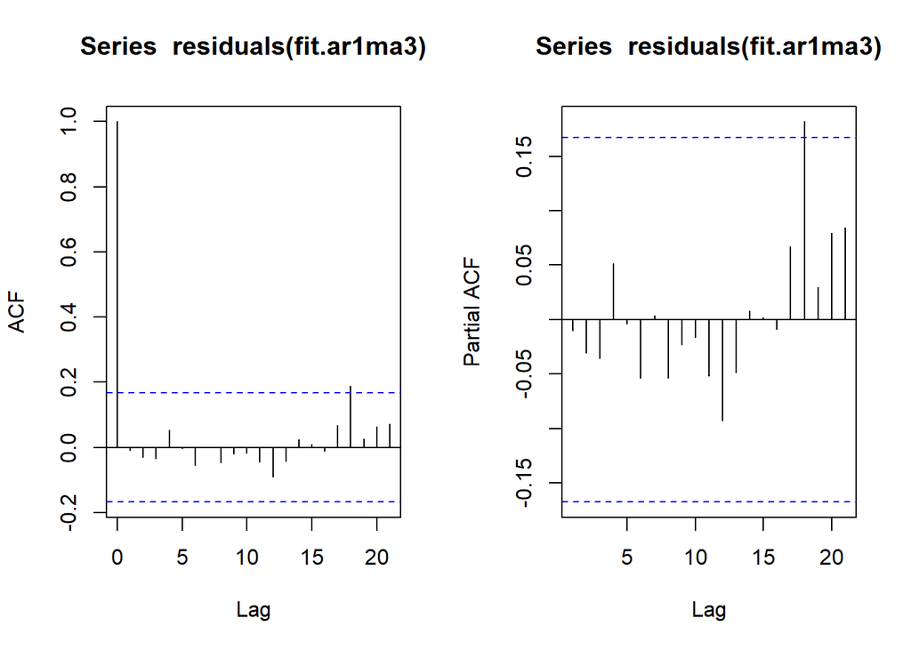

We used Ljung-Box test to see if correlation is indepedent. They all pasted the teat. They all have few stabs at the same place, but we consider they all fit well enough, because an unexplained increase of temperature is in the data set. The extremity is between 1940 and 1945, the years World War 2 occurred. The models’ abnormal stabs are due to the war’s strain on the climate.